# ExtraaLearn Project

## Context

The EdTech industry has been surging in the past decade immensely, and according to a forecast, the Online Education market would be worth $286.62bn by 2023 with a compound annual growth rate (CAGR) of 10.26% from 2018 to 2023. The modern era of online education has enforced a lot in its growth and expansion beyond any limit. Due to having many dominant features like ease of information sharing, personalized learning experience, transparency of assessment, etc, it is now preferable to traditional education.

In the present scenario due to the Covid-19, the online education sector has witnessed rapid growth and is attracting a lot of new customers. Due to this rapid growth, many new companies have emerged in this industry. With the availability and ease of use of digital marketing resources, companies can reach out to a wider audience with their offerings. The customers who show interest in these offerings are termed as leads. There are various sources of obtaining leads for Edtech companies, like

- The customer interacts with the marketing front on social media or other online platforms.
- The customer browses the website/app and downloads the brochure
- The customer connects through emails for more information.

The company then nurtures these leads and tries to convert them to paid customers. For this, the representative from the organization connects with the lead on call or through email to share further details.

## Objective

ExtraaLearn is an initial stage startup that offers programs on cutting-edge technologies to students and professionals to help them upskill/reskill. With a large number of leads being generated on a regular basis, one of the issues faced by ExtraaLearn is to identify which of the leads are more likely to convert so that they can allocate resources accordingly. You, as a data scientist at ExtraaLearn, have been provided the leads data to:

- Analyze and build an ML model to help identify which leads are more likely to convert to paid customers,
- Find the factors driving the lead conversion process
- Create a profile of the leads which are likely to convert

## Data Description

The data contains the different attributes of leads and their interaction details with ExtraaLearn. The detailed data dictionary is given below.

**Data Dictionary**

- ID: ID of the lead
- age: Age of the lead
- current_occupation: Current occupation of the lead. Values include 'Professional','Unemployed',and 'Student'
- first_interaction: How did the lead first interacted with ExtraaLearn. Values include 'Website', 'Mobile App'
- profile_completed: What percentage of profile has been filled by the lead on the website/mobile app. Values include Low - (0-50%), Medium - (50-75%), High (75-100%)
- website_visits: How many times has a lead visited the website
- time_spent_on_website: Total time spent on the website
- page_views_per_visit: Average number of pages on the website viewed during the visits.
- last_activity: Last interaction between the lead and ExtraaLearn.
  - Email Activity: Seeking for details about program through email, Representative shared information with lead like brochure of program , etc
  - Phone Activity: Had a Phone Conversation with representative, Had conversation over SMS with representative, etc
  - Website Activity: Interacted on live chat with representative, Updated profile on website, etc
- print_media_type1: Flag indicating whether the lead had seen the ad of ExtraaLearn in the Newspaper.
- print_media_type2: Flag indicating whether the lead had seen the ad of ExtraaLearn in the Magazine.
- digital_media: Flag indicating whether the lead had seen the ad of ExtraaLearn on the digital platforms.
- educational_channels: Flag indicating whether the lead had heard about ExtraaLearn in the education channels like online forums, discussion threads, educational websites, etc.
- referral: Flag indicating whether the lead had heard about ExtraaLearn through reference.
- status: Flag indicating whether the lead was converted to a paid customer or not.

## Importing necessary libraries and data

```python
import numpy as np
import pandas as pd
import matplotlib.pyplot as plt
import seaborn as sns
from scipy import stats
from sklearn.model_selection import train_test_split, GridSearchCV
from sklearn.preprocessing import OneHotEncoder
from sklearn.tree import DecisionTreeClassifier, plot_tree
from sklearn.ensemble import RandomForestClassifier
from sklearn.metrics import confusion_matrix, ConfusionMatrixDisplay, classification_report
from sklearn.utils import resample
```

## Data Overview

```python
# Load dataset (we will call default/initial dataset df0 and any subsequent transformations on the dataset will be incremented by 1, e.g. df1, df2, ... ,etc.)
filepath1 = 'ExtraaLearn.csv'
df0 = pd.read_csv(filepath1, header = 0)
df0.sample(5)
```

|  | ID | age | current_occupation | first_interaction | profile_completed | website_visits | time_spent_on_website | page_views_per_visit | last_activity | print_media_type1 | print_media_type2 | digital_media | educational_channels | referral | status |
| --- | --- | --- | --- | --- | --- | --- | --- | --- | --- | --- | --- | --- | --- | --- | --- |
| 1420 | EXT1421 | 56 | Professional | Website | High | 6 | 230 | 4.287 | Website Activity | No | No | No | No | No | 0 |
| 4268 | EXT4269 | 52 | Professional | Website | High | 1 | 389 | 3.235 | Website Activity | No | No | No | No | No | 1 |
| 3523 | EXT3524 | 32 | Unemployed | Mobile App | High | 2 | 2034 | 0.120 | Email Activity | No | No | No | No | No | 0 |
| 4110 | EXT4111 | 23 | Student | Mobile App | Medium | 6 | 220 | 2.247 | Phone Activity | No | No | No | No | No | 0 |
| 1790 | EXT1791 | 55 | Professional | Website | High | 2 | 112 | 3.334 | Phone Activity | No | No | No | No | No | 0 |

```python
# Get info on dataset
df0.info()
```

```
<class 'pandas.core.frame.DataFrame'>
RangeIndex: 4612 entries, 0 to 4611
Data columns (total 15 columns):
 #   Column                 Non-Null Count  Dtype
---  ------                 --------------  -----
 0   ID                     4612 non-null   object
 1   age                    4612 non-null   int64
 2   current_occupation     4612 non-null   object
 3   first_interaction      4612 non-null   object
 4   profile_completed      4612 non-null   object
 5   website_visits         4612 non-null   int64
 6   time_spent_on_website  4612 non-null   int64
 7   page_views_per_visit   4612 non-null   float64
 8   last_activity          4612 non-null   object
 9   print_media_type1      4612 non-null   object
 10  print_media_type2      4612 non-null   object
 11  digital_media          4612 non-null   object
 12  educational_channels   4612 non-null   object
 13  referral               4612 non-null   object
 14  status                 4612 non-null   int64
dtypes: float64(1), int64(4), object(10)
memory usage: 540.6+ KB
```

```python
# All columns in data
all_cols = df0.columns.values
all_cols
```

```
array(['ID', 'age', 'current_occupation', 'first_interaction',
       'profile_completed', 'website_visits', 'time_spent_on_website',
       'page_views_per_visit', 'last_activity', 'print_media_type1',
       'print_media_type2', 'digital_media', 'educational_channels',
       'referral', 'status'], dtype=object)
```

```python
# Get y_col: target
y_col = 'status'
y_col
```

```
'status'
```

```python
# Ignore target column and columns that identify data rows
ignore_cols = [y_col] + ['ID']

# Get x_cols: predictors
cond = ~np.isin(all_cols, ignore_cols)
x_cols = all_cols[cond]
x_cols
```

```
array(['age', 'current_occupation', 'first_interaction',
       'profile_completed', 'website_visits', 'time_spent_on_website',
       'page_views_per_visit', 'last_activity', 'print_media_type1',
       'print_media_type2', 'digital_media', 'educational_channels',
       'referral'], dtype=object)
```

```python
# New dataframe with dropped column
df1 = df0.copy()[[y_col, *x_cols]]
# df1[y_col] = df1[y_col].astype('object')
df1.info()
```

```
<class 'pandas.core.frame.DataFrame'>
RangeIndex: 4612 entries, 0 to 4611
Data columns (total 14 columns):
 #   Column                 Non-Null Count  Dtype
---  ------                 --------------  -----
 0   status                 4612 non-null   int64
 1   age                    4612 non-null   int64
 2   current_occupation     4612 non-null   object
 3   first_interaction      4612 non-null   object
 4   profile_completed      4612 non-null   object
 5   website_visits         4612 non-null   int64
 6   time_spent_on_website  4612 non-null   int64
 7   page_views_per_visit   4612 non-null   float64
 8   last_activity          4612 non-null   object
 9   print_media_type1      4612 non-null   object
 10  print_media_type2      4612 non-null   object
 11  digital_media          4612 non-null   object
 12  educational_channels   4612 non-null   object
 13  referral               4612 non-null   object
dtypes: float64(1), int64(4), object(9)
memory usage: 504.6+ KB
```

```python
# Check to see if values are missing in any of the columns
df1.isna().sum()
```

```
status                   0
age                      0
current_occupation       0
first_interaction        0
profile_completed        0
website_visits           0
time_spent_on_website    0
page_views_per_visit     0
last_activity            0
print_media_type1        0
print_media_type2        0
digital_media            0
educational_channels     0
referral                 0
dtype: int64
```

```python
# Numeric x variables
x_cols_numeric = df1[x_cols].select_dtypes(include = 'number').columns.values
x_cols_numeric
```

```
array(['age', 'website_visits', 'time_spent_on_website',
       'page_views_per_visit'], dtype=object)
```

```python
# Object x variables
x_cols_object = df1[x_cols].select_dtypes(include = 'object').columns.values
x_cols_object
```

```
array(['current_occupation', 'first_interaction', 'profile_completed',
       'last_activity', 'print_media_type1', 'print_media_type2',
       'digital_media', 'educational_channels', 'referral'], dtype=object)
```

## Exploratory Data Analysis (EDA)

```python
# Colors
c_scale = 256
c1 = (1, 1, 1) # grey
c2 = (1, 0, 0) # red
c3 = (181/c_scale, 204/c_scale, 6/c_scale) # yellow
c4 = (6/c_scale, 122/c_scale, 204/c_scale) # blue
c5 = (0, 0, 0) # black
```

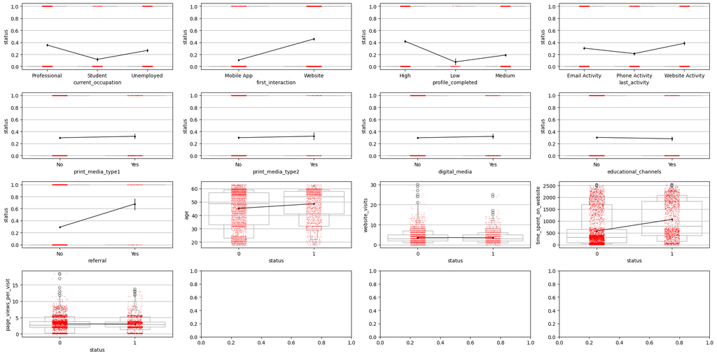

```python
# Figure setup
fig_cols = 4
fig_rows = np.ceil(len(x_cols)/fig_cols).astype('int')
n_levels = df1[y_col].unique().size
palette1 = [c1 for i in range(n_levels)]
palette2 = [c3, c4]
figsize = (20, 10)

# Subplot of y vs each x (stripplot + violinplot + boxenplot)
f1, axes = plt.subplots(fig_rows, fig_cols, figsize = figsize)
itr = 0
for x in [*x_cols_object, *x_cols_numeric]:
  row = np.floor(itr/fig_cols)
  row = row.astype('int')
  col = np.mod(itr, fig_cols)
  col = col.astype('int')
  if x in x_cols_object:
    x_order = np.sort(df1[x].unique())
    p1 = sns.boxenplot(ax = axes[row, col], data = df1, y = y_col, x = x, hue = y_col, palette = palette1, order = x_order)
    p2 = sns.stripplot(ax = axes[row, col], data = df1, y = y_col, x = x, color = c2, size = 1, order = x_order)
    p3 = sns.pointplot(ax = axes[row, col], data = df1, y = y_col, x = x, color = c5, linewidth = 1, order = x_order)
  else:
    p1 = sns.boxenplot(ax = axes[row, col], data = df1, x = y_col, y = x, hue = y_col, palette = palette1)
    p2 = sns.stripplot(ax = axes[row, col], data = df1, x = y_col, y = x, color = c2, size = 1)
    p3 = sns.pointplot(ax = axes[row, col], data = df1, x = y_col, y = x, color = c5, linewidth = 1)

  p1.grid(visible = True, which = 'both', axis = 'y')
  axes[row, col].legend_ = None
  itr = itr + 1

# Tighten layout to avoid text overlapping grpah
f1.tight_layout()
```

**Observations**

## Data Preprocessing

```python
# User defined function to identify outliers using interquartile range
def jra_identify_outliers_iqr(x):
  # Get Q1 and Q3 quantiles
  q1, q3 = np.quantile(x, q = [0.25, 0.75])
  # Calculate interquartile range
  iqr = q3 - q1
  # Outlier factor
  factor = (1.5 * iqr)
  # Lower bound for outliers
  lb = q1 - factor
  # Upper bound for outliers
  ub = q3 + factor
  # Outlier identification
  cond = (x < lb) | (x > ub)
  return cond

# User defined function to identify outliers using z-score
def jra_identify_outliers_zscore(x):
  # x = df1['page_views_per_visit']
  # Get z-scores
  z_scores = stats.zscore(x)
  # Outlier factor
  factor = 3
  # Outlier identification
  cond = np.abs(z_scores) > factor
  return cond
```

```python
# Systematically remove outliers from each x_col
df2 = df1.copy()
for x in x_cols_numeric:
# for x in ['time_spent_on_website']:
  cond = ~jra_identify_outliers_iqr(df2[x])
  # cond = ~jra_identify_outliers_zscore(df2[x])
  df2 = df2.loc[cond,:]

n_df1 = df1.shape[0]
n_df2 = df2.shape[0]
outliers_removed = n_df1 - n_df2
print(f'{n_df1} points in initial dataset')
print(f'{n_df2} points in new dataset')
print(f'{outliers_removed} outliers were removed from the dataset')
```

```
4612 points in initial dataset
4208 points in new dataset
404 outliers were removed from the dataset
```

```python
# Target label dictionary
y_labels = ['lead_converted', 'lead_not_converted']
y_labels = {y_labels[i]: i for i in range(len(y_labels))}
y_labels
```

```
{'lead_converted': 0, 'lead_not_converted': 1}
```

```python
# Set random state value for consistency
random_state = 1
```

```python
# Systematically balance target label distribution
temp = list(y_labels.values())
cond1 = df2[y_col] == temp[0]
cond2 = df2[y_col] == temp[1]

n_1 = np.sum(cond1)
n_2 = np.sum(cond2)
print(f'Initial count of class = {temp[0]}: {n_1}')
print(f'Initial count of class = {temp[1]}: {n_2}')


# Upsample minority label
df_temp = df2.loc[cond2,:]
n_diff = n_1 - n_2
print('')
print(f'Amount to upsample to minority label: {n_diff }')

df_upsample = resample(
  df_temp,
  replace = True,
  n_samples = n_diff,
  random_state = random_state
)

# New dataframe with upsampled class labels
df3 = pd.concat([df2, df_upsample], ignore_index = True)


temp = list(y_labels.values())
cond1 = df3[y_col] == temp[0]
cond2 = df3[y_col] == temp[1]
n_1 = np.sum(cond1)
n_2 = np.sum(cond2)
print('')
print(f'Final count of class = {temp[0]}: {n_1}')
print(f'Final count of class = {temp[1]}: {n_2}')
```

```
Initial count of class = 0: 2939
Initial count of class = 1: 1269

Amount to upsample to minority label: 1670

Final count of class = 0: 2939
Final count of class = 1: 2939
```

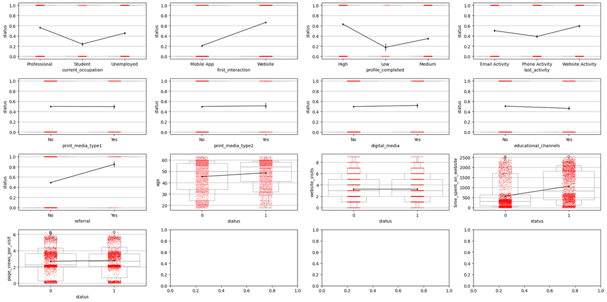

```python
# Subplot of y vs each x (stripplot + violinplot + boxenplot)
f1, axes = plt.subplots(fig_rows, fig_cols, figsize = figsize)
itr = 0
for x in [*x_cols_object, *x_cols_numeric]:
  row = np.floor(itr/fig_cols)
  row = row.astype('int')
  col = np.mod(itr, fig_cols)
  col = col.astype('int')
  # p1 = sns.violinplot(ax = axes[row, col], data = df2, x = y_col, y = x, hue = y_col, palette = palette1)
  if x in x_cols_object:
    x_order = np.sort(df3[x].unique())
    p1 = sns.boxenplot(ax = axes[row, col], data = df3, y = y_col, x = x, hue = y_col, palette = palette1, order = x_order)
    p2 = sns.stripplot(ax = axes[row, col], data = df3, y = y_col, x = x, color = c2, size = 1, order = x_order)
    p3 = sns.pointplot(ax = axes[row, col], data = df3, y = y_col, x = x, color = c5, linewidth = 1, order = x_order)
  else:
    p1 = sns.boxenplot(ax = axes[row, col], data = df3, x = y_col, y = x, hue = y_col, palette = palette1)
    p2 = sns.stripplot(ax = axes[row, col], data = df3, x = y_col, y = x, color = c2, size = 1)
    p3 = sns.pointplot(ax = axes[row, col], data = df3, x = y_col, y = x, color = c5, linewidth = 1)
    # p4 = sns.boxplot(ax = axes[row, col], data = df3, x = y_col, y = x, color = c5, linewidth = 1)


  p1.grid(visible = True, which = 'both', axis = 'y')
  axes[row, col].legend_ = None
  itr = itr + 1

# Tighten layout to avoid text overlapping grpah
f1.tight_layout()
```

**Observations**

1. Current occupation affects potential expected leads in the following way: Professional has the highest expectation (approx. 0.6), followed by Unemployed (approx. 0.5), then Student (approx. 0.3).
2. The first channels of interaction have an impact on the lead status: Website interactions result in a 3 times higher lead expectation (approx. 0.6) compared to Mobile App (approx. 0.2).
3. Website activity (live chat) is the best mode of interaction with prospective leads (approx. 0.6 conversion rate), compared to email and phone activity (approx. 0.5 and 0.4 conversion rates, respectively.)
4. Referrals seem to have the highest expectation on lead conversion rates (approx. 0.8) compared to the other channels which are all much less this rate.
5. Having more details about a prospect increases the chances of conversion. A high, medium, and low percentage of the profile completed yeilds conversion rates of approx. 0.6, 0.4, and 0.2, respectively.

```python
# Drop x_cols that show little to no variability in the expected target outcome (ignored after the fact)
# drop_cols = ['page_views_per_visit', 'print_media_type1', 'print_media_type2', 'website_visits', 'digital_media']
# x_cols2 = [x for x in x_cols if x not in drop_cols]
x_cols2 = x_cols.copy()
x_cols2
```

```
array(['age', 'current_occupation', 'first_interaction',
       'profile_completed', 'website_visits', 'time_spent_on_website',
       'page_views_per_visit', 'last_activity', 'print_media_type1',
       'print_media_type2', 'digital_media', 'educational_channels',
       'referral'], dtype=object)
```

```python
# Handle categorical columns using one-hot-encoding (not dropping first)
df4 = df3.copy()
onehot = OneHotEncoder(handle_unknown = 'ignore', drop = 'first', dtype = 'int')
label_cols = df4[x_cols2].select_dtypes(include = 'object').columns
df_temp = pd.DataFrame(onehot.fit_transform(df4[label_cols]).toarray())
df_temp.columns = onehot.get_feature_names_out()
df_temp = pd.concat([df4[x_cols2], df_temp], axis = 1).drop(columns = label_cols, errors = 'ignore')
df_temp = df_temp.reindex(labels = sorted(df_temp.columns), axis = 1)
df5 = pd.concat([df4[y_col], df_temp], axis = 1)
df5.info()
```

```
<class 'pandas.core.frame.DataFrame'>
RangeIndex: 5878 entries, 0 to 5877
Data columns (total 17 columns):
 #   Column                          Non-Null Count  Dtype
---  ------                          --------------  -----
 0   status                          5878 non-null   int64
 1   age                             5878 non-null   int64
 2   current_occupation_Student      5878 non-null   int32
 3   current_occupation_Unemployed   5878 non-null   int32
 4   digital_media_Yes               5878 non-null   int32
 5   educational_channels_Yes        5878 non-null   int32
 6   first_interaction_Website       5878 non-null   int32
 7   last_activity_Phone Activity    5878 non-null   int32
 8   last_activity_Website Activity  5878 non-null   int32
 9   page_views_per_visit            5878 non-null   float64
 10  print_media_type1_Yes           5878 non-null   int32
 11  print_media_type2_Yes           5878 non-null   int32
 12  profile_completed_Low           5878 non-null   int32
 13  profile_completed_Medium        5878 non-null   int32
 14  referral_Yes                    5878 non-null   int32
 15  time_spent_on_website           5878 non-null   int64
 16  website_visits                  5878 non-null   int64
dtypes: float64(1), int32(12), int64(4)
memory usage: 505.3 KB
```

## Building a Decision Tree model

```python
# Get new x_cols: predictors
all_cols2 = df5.columns.values
cond = ~np.isin(all_cols2, [y_col])
x_cols3 = all_cols2[cond]
x_cols3
```

```
array(['age', 'current_occupation_Student',
       'current_occupation_Unemployed', 'digital_media_Yes',
       'educational_channels_Yes', 'first_interaction_Website',
       'last_activity_Phone Activity', 'last_activity_Website Activity',
       'page_views_per_visit', 'print_media_type1_Yes',
       'print_media_type2_Yes', 'profile_completed_Low',
       'profile_completed_Medium', 'referral_Yes',
       'time_spent_on_website', 'website_visits'], dtype=object)
```

```python
# Split data into train and test datasets
X = df5[x_cols3]
y = df5[y_col]

X_train, X_test, y_train, y_test = train_test_split(X, y,
  stratify = y, shuffle = True,
  train_size = 0.8, random_state = random_state
)
```

```python
# Build decision tree classifier
dtree_clf = DecisionTreeClassifier(criterion = 'entropy', random_state = random_state)
```

```python
# Fit classifier to data
temp = dtree_clf.fit(X_train, y_train)
```

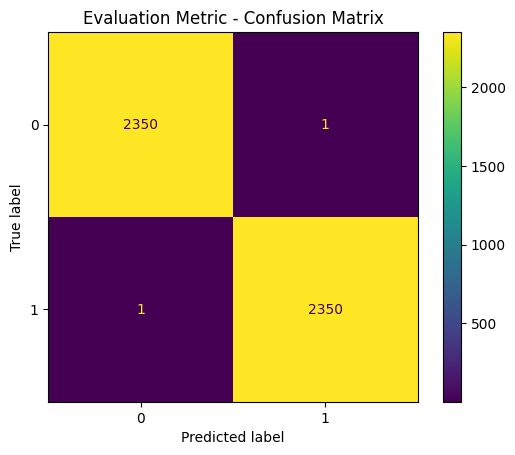

```python
# Get predictions on train data
y_hat = dtree_clf.predict(X_train)

# Evaluate training model using confusion matrix
cm = confusion_matrix(y_true = y_train, y_pred = y_hat)

p1 = ConfusionMatrixDisplay(confusion_matrix = cm)
p1.plot()
plt.title('Evaluation Metric - Confusion Matrix')
plt.show()
```

```python
# Evaluate training model using confusion matrix using recall, precision , F1-score
metric_report = classification_report(y_true = y_train, y_pred = y_hat, output_dict = False, zero_division = 0)
print(metric_report)
```

```
              precision    recall  f1-score   support

           0       1.00      1.00      1.00      2351
           1       1.00      1.00      1.00      2351

    accuracy                           1.00      4702
   macro avg       1.00      1.00      1.00      4702
weighted avg       1.00      1.00      1.00      4702
```

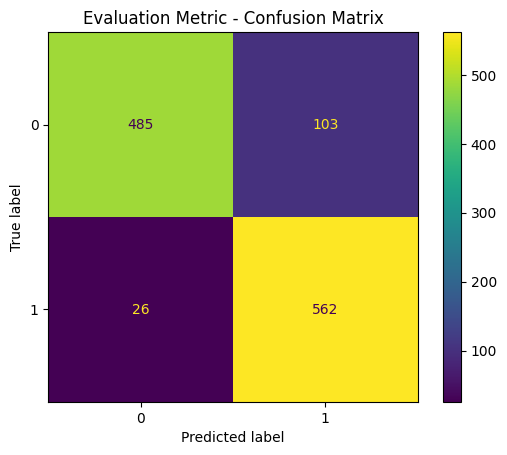

```python
# Get predictions on test data
y_hat = dtree_clf.predict(X_test)

# Evaluate training model using confusion matrix
cm = confusion_matrix(y_true = y_test, y_pred = y_hat)

p1 = ConfusionMatrixDisplay(confusion_matrix = cm)
p1.plot()
plt.title('Evaluation Metric - Confusion Matrix')
plt.show()
```

```python
# Evaluate testing model using confusion matrix using recall, precision , F1-score
metric_report = classification_report(y_true = y_test, y_pred = y_hat, output_dict = False, zero_division = 0)
print(metric_report)
```

```
              precision    recall  f1-score   support

           0       0.95      0.82      0.88       588
           1       0.85      0.96      0.90       588

    accuracy                           0.89      1176
   macro avg       0.90      0.89      0.89      1176
weighted avg       0.90      0.89      0.89      1176
```

**Observations**

1. Note: we care about model precision for predicting class = 1 (i.e. lead converted) because false positives/leads would be the worst case for us.
2. The training dataset performance is overfitting because trainning model performance (i.e. precision) is perfect while the testing model performance is not perfect, i.e. 85%

## Do we need to prune the tree?

**Observation**: Yes, pruning the tree is needed given the disparity between the training and testing performance.

```python
# Get best decision tree model paramaters using grid search
parameters = {
  "max_depth": np.arange(1,10,1),
  "max_leaf_nodes": np.arange(50,150,10),
  "min_samples_split": np.arange(10,50,10)
}
dtree_clf = DecisionTreeClassifier(criterion = 'entropy', random_state = random_state)
cv = GridSearchCV(dtree_clf, param_grid = parameters, cv = 5)
cv.fit(X_train, y_train)
```

```
GridSearchCV(cv=5,
             estimator=DecisionTreeClassifier(criterion='entropy',
                                              random_state=1),
             param_grid={'max_depth': array([1, 2, 3, 4, 5, 6, 7, 8, 9]),
                         'max_leaf_nodes': array([ 50,  60,  70,  80,  90, 100, 110, 120, 130, 140]),
                         'min_samples_split': array([10, 20, 30, 40])})
```

```python
# Retrain model with best best grid search parameters
dtree_clf = DecisionTreeClassifier(
  criterion = 'entropy',
  max_depth =  cv.best_params_['max_depth'],
  max_leaf_nodes = cv.best_params_['max_leaf_nodes'],
  min_samples_split =  cv.best_params_['min_samples_split'],
  random_state = random_state
)
```

```python
# Fit classifier to trainning data
temp = dtree_clf.fit(X_train, y_train)
```

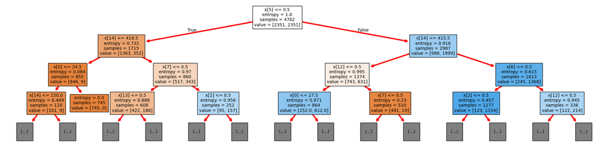

```
x[0]: age
x[1]: current_occupation_Student
x[2]: current_occupation_Unemployed
x[3]: digital_media_Yes
x[4]: educational_channels_Yes
x[5]: first_interaction_Website
x[6]: last_activity_Phone Activity
x[7]: last_activity_Website Activity
x[8]: page_views_per_visit
x[9]: print_media_type1_Yes
x[10]: print_media_type2_Yes
x[11]: profile_completed_Low
x[12]: profile_completed_Medium
x[13]: referral_Yes
x[14]: time_spent_on_website
x[15]: website_visits
```

```python
# Show decision tree visual used for training
fig, ax = plt.subplots(figsize = (25, 6))
out = plot_tree(dtree_clf, filled = True, fontsize = 10, max_depth = 3)
for o in out:
  arrow = o.arrow_patch
  if arrow is not None:
    arrow.set_edgecolor('red')
    arrow.set_linewidth(3)
plt.show()

# Print feature_key
feature_list = dtree_clf.feature_names_in_
temp = [print(f'x[{i}]: {feature_list[i]}') for i in range(len(feature_list))]
```

```python
# Get feature importance
df_feature_importance = pd.DataFrame({
  'Feature': dtree_clf.feature_names_in_,
  'Relative Importance [%]': np.round(dtree_clf.feature_importances_ * 100, 1)
}).sort_values(by = 'Relative Importance [%]', ascending = False)

df_feature_importance
```

|  | Feature | Relative Importance [%] |
| --- | --- | --- |
| 14 | time_spent_on_website | 26.8 |
| 5 | first_interaction_Website | 24.1 |
| 12 | profile_completed_Medium | 20.9 |
| 0 | age | 6.0 |
| 7 | last_activity_Website Activity | 4.4 |
| 6 | last_activity_Phone Activity | 3.7 |
| 2 | current_occupation_Unemployed | 3.4 |
| 8 | page_views_per_visit | 3.0 |
| 1 | current_occupation_Student | 2.6 |
| 11 | profile_completed_Low | 2.6 |
| 13 | referral_Yes | 1.2 |
| 15 | website_visits | 0.8 |
| 4 | educational_channels_Yes | 0.3 |
| 3 | digital_media_Yes | 0.0 |
| 9 | print_media_type1_Yes | 0.0 |
| 10 | print_media_type2_Yes | 0.0 |

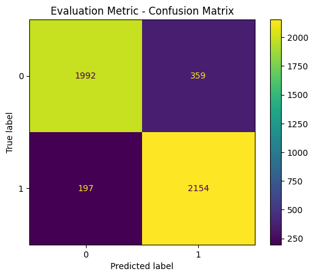

```python
# Get predictions on train data
y_hat = dtree_clf.predict(X_train)

# Evaluate training model using confusion matrix
cm = confusion_matrix(y_true = y_train, y_pred = y_hat)

p1 = ConfusionMatrixDisplay(confusion_matrix = cm)
p1.plot()
plt.title('Evaluation Metric - Confusion Matrix')
plt.show()
```

```python
# Evaluate training model using confusion matrix using recall, precision , F1-score
metric_report = classification_report(y_true = y_train, y_pred = y_hat, output_dict = False, zero_division = 0)
print(metric_report)
```

```
              precision    recall  f1-score   support

           0       0.91      0.85      0.88      2351
           1       0.86      0.92      0.89      2351

    accuracy                           0.88      4702
   macro avg       0.88      0.88      0.88      4702
weighted avg       0.88      0.88      0.88      4702
```

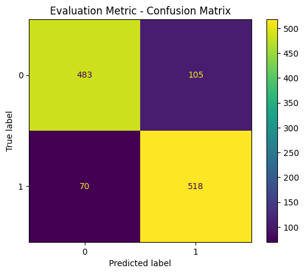

```python
# Get predictions on test data
y_hat = dtree_clf.predict(X_test)

# Evaluate training model using confusion matrix
cm = confusion_matrix(y_true = y_test, y_pred = y_hat)

p1 = ConfusionMatrixDisplay(confusion_matrix = cm)
p1.plot()
plt.title('Evaluation Metric - Confusion Matrix')
plt.show()
```

```python
# Evaluate testing model using confusion matrix using recall, precision , F1-score
metric_report = classification_report(y_true = y_test, y_pred = y_hat, output_dict = False, zero_division = 0)
print(metric_report)
```

```
              precision    recall  f1-score   support

           0       0.87      0.82      0.85       588
           1       0.83      0.88      0.86       588

    accuracy                           0.85      1176
   macro avg       0.85      0.85      0.85      1176
weighted avg       0.85      0.85      0.85      1176
```

## Building a Random Forest model

```python
# Build random forest classifier
rf_clf = RandomForestClassifier(criterion = 'entropy', random_state = random_state)
```

```python
# Fit classifier to data
temp = rf_clf.fit(X_train, y_train)
```

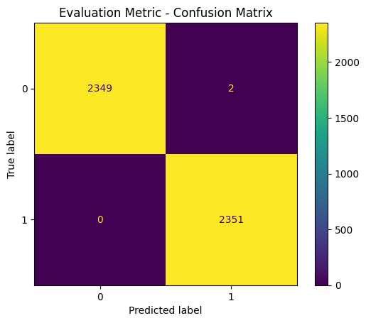

```python
# Get predictions on train data
y_hat = rf_clf.predict(X_train)

# Evaluate training model using confusion matrix
cm = confusion_matrix(y_true = y_train, y_pred = y_hat)

p1 = ConfusionMatrixDisplay(confusion_matrix = cm)
p1.plot()
plt.title('Evaluation Metric - Confusion Matrix')
plt.show()
```

```python
# Evaluate training model using confusion matrix using recall, precision , F1-score
metric_report = classification_report(y_true = y_train, y_pred = y_hat, output_dict = False, zero_division = 0)
print(metric_report)
```

```
              precision    recall  f1-score   support

           0       1.00      1.00      1.00      2351
           1       1.00      1.00      1.00      2351

    accuracy                           1.00      4702
   macro avg       1.00      1.00      1.00      4702
weighted avg       1.00      1.00      1.00      4702
```

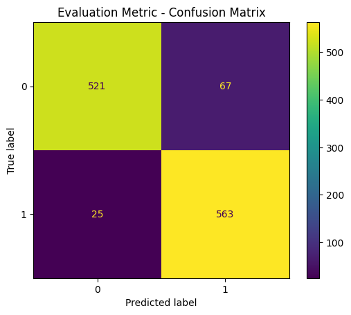

```python
# Get predictions on test data
y_hat = rf_clf.predict(X_test)

# Evaluate training model using confusion matrix
cm = confusion_matrix(y_true = y_test, y_pred = y_hat)

p1 = ConfusionMatrixDisplay(confusion_matrix = cm)
p1.plot()
plt.title('Evaluation Metric - Confusion Matrix')
plt.show()
```

```python
# Evaluate testing model using confusion matrix using recall, precision , F1-score
metric_report = classification_report(y_true = y_test, y_pred = y_hat, output_dict = False, zero_division = 0)
print(metric_report)
```

```
              precision    recall  f1-score   support

           0       0.95      0.89      0.92       588
           1       0.89      0.96      0.92       588

    accuracy                           0.92      1176
   macro avg       0.92      0.92      0.92      1176
weighted avg       0.92      0.92      0.92      1176
```

**Observations**

## Do we need to prune the tree?

**Observation**: Yes, pruning the tree is needed given the disparity between the training and testing performance.

```python
# Get best random forest model paramaters using grid search
parameters = {
  'n_estimators': np.arange(25, 100, 25),
  'max_depth': np.arange(3, 9, 3),
  'max_leaf_nodes': np.arange(3, 9, 3),
}
rf_clf = RandomForestClassifier(criterion = 'entropy', random_state = random_state)
cv = GridSearchCV(rf_clf, param_grid = parameters, cv = 5)
temp = cv.fit(X_train, y_train)
print(cv.best_params_)
```

```
{'max_depth': 3, 'max_leaf_nodes': 6, 'n_estimators': 25}
```

```python
# Retrain model with best best grid search parameters
rf_clf = RandomForestClassifier(
  criterion = 'entropy',
  n_estimators =  cv.best_params_['n_estimators'],
  max_depth =  cv.best_params_['max_depth'],
  max_leaf_nodes = cv.best_params_['max_leaf_nodes'],
  random_state = random_state
)
```

```python
# Fit classifier to trainning data
temp = rf_clf.fit(X_train, y_train)
```

```python
# Get feature importance
df_feature_importance = pd.DataFrame({
  'Feature': rf_clf.feature_names_in_,
  'Relative Importance [%]': np.round(rf_clf.feature_importances_ * 100, 1)
}).sort_values(by = 'Relative Importance [%]', ascending = False)

df_feature_importance
```

|  | Feature | Relative Importance [%] |
| --- | --- | --- |
| 5 | first_interaction_Website | 35.1 |
| 14 | time_spent_on_website | 30.8 |
| 12 | profile_completed_Medium | 13.8 |
| 0 | age | 5.6 |
| 1 | current_occupation_Student | 4.5 |
| 6 | last_activity_Phone Activity | 3.6 |
| 13 | referral_Yes | 2.3 |
| 7 | last_activity_Website Activity | 1.8 |
| 2 | current_occupation_Unemployed | 0.8 |
| 8 | page_views_per_visit | 0.7 |
| 11 | profile_completed_Low | 0.7 |
| 15 | website_visits | 0.3 |
| 4 | educational_channels_Yes | 0.1 |
| 3 | digital_media_Yes | 0.0 |
| 9 | print_media_type1_Yes | 0.0 |
| 10 | print_media_type2_Yes | 0.0 |

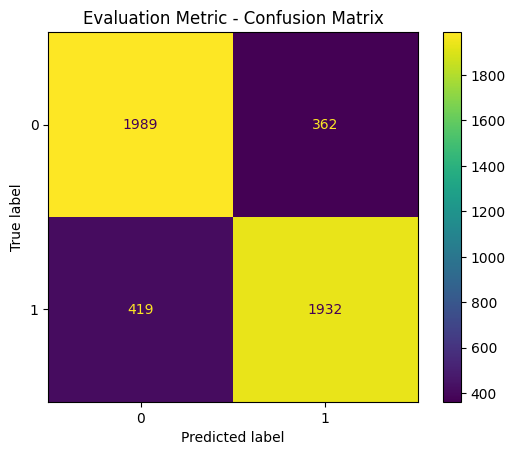

```python
# Get predictions on train data
y_hat = rf_clf.predict(X_train)

# Evaluate training model using confusion matrix
cm = confusion_matrix(y_true = y_train, y_pred = y_hat)

p1 = ConfusionMatrixDisplay(confusion_matrix = cm)
p1.plot()
plt.title('Evaluation Metric - Confusion Matrix')
plt.show()
```

```python
# Evaluate training model using confusion matrix using recall, precision , F1-score
metric_report = classification_report(y_true = y_train, y_pred = y_hat, output_dict = False, zero_division = 0)
print(metric_report)
```

```
              precision    recall  f1-score   support

           0       0.83      0.85      0.84      2351
           1       0.84      0.82      0.83      2351

    accuracy                           0.83      4702
   macro avg       0.83      0.83      0.83      4702
weighted avg       0.83      0.83      0.83      4702
```

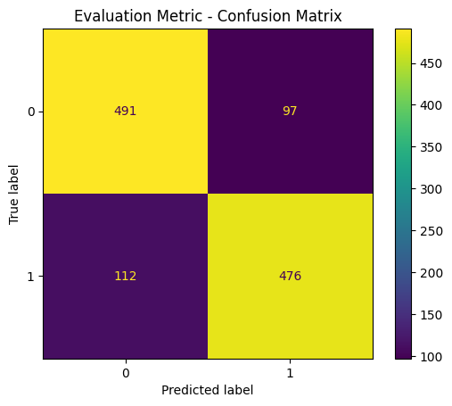

```python
# Get predictions on test data
y_hat = rf_clf.predict(X_test)

# Evaluate training model using confusion matrix
cm = confusion_matrix(y_true = y_test, y_pred = y_hat)

p1 = ConfusionMatrixDisplay(confusion_matrix = cm)
p1.plot()
plt.title('Evaluation Metric - Confusion Matrix')
plt.show()
```

```python
# Evaluate testing model using confusion matrix using recall, precision , F1-score
metric_report = classification_report(y_true = y_test, y_pred = y_hat, output_dict = False, zero_division = 0)
print(metric_report)
```

```
              precision    recall  f1-score   support

           0       0.81      0.84      0.82       588
           1       0.83      0.81      0.82       588

    accuracy                           0.82      1176
   macro avg       0.82      0.82      0.82      1176
weighted avg       0.82      0.82      0.82      1176
```

## Actionable Insights and Recommendations

### Conclusions:

- The top 3 features in predicting whether a lead is converted to a paid customer or not are: (1) whether the lead first intereacted with ExtraaLearn via a website or not, (2) the total time spent on the website, and (3) whether 50-70% of the profle has been filled by the lead on the website/mobile app.
- The top 3 features are the case irrespective of whether a decision tree or random forest model was fit to the data.
- From exploratory data analysis after balancing the data, first interaction via website has a more than tripple expectation of the lead converting to a paid customer versus first interaction via mobile app (i.e. 0.6 vesus 0.2).
- From exploratory data analysis after balancing the data, more time spent on website results in more expected lead conversions.

### Recommendations:

- Converting leads to paid customers greatly depends on whether the first interaction was via website, therefore it is important that the website content is well targeted towards it's intended audiences.
- More so, when leads interact with the website, it is importnt to engage them via live chat to keep them on the website longer or at least present ad-based incentives/promotions for the lead to want to fill out an online profile at least half of the way; the more the better chance of conversion
- Activity on the website can be followed up with secondary targeted means of interaction (e.g. Mobile App notifications) to get the lead to get back on the website or prompting them to complete their online profile with the benefit of a timely promotion/incentive if completed soon.